# cns_early_voting_taylor

Taylor Nichols

2024-10-29

```r
library(tidyverse)
library(janitor)
```

```r
library(ggplot2)
library(tidycensus)
```

```r
early_voting <- read_csv("EarlyVoting RAW data.csv") |>
  clean_names()
```

```r
# Get total population and population 18 and older
adult_pop <- get_acs(geography =  "county",
                     state = "24",
                     variables = c(adults_18_plus = "B01001_026"),
                     year = 2021)
adult_pop <- adult_pop |>
    mutate(NAME = case_when(
        NAME == "Baltimore County, Maryland" ~ str_replace(NAME, ", Maryland", ""),  # Trim ", Maryland" for Baltimore
        TRUE ~ str_replace(NAME, "County, Maryland", "")  # Trim "County, Maryland" for the rest
    )) |>
    mutate(NAME = str_replace(NAME, "city, Maryland", "City"),  # Correct case sensitivity
           NAME = str_replace(NAME, "St.", "Saint")) |>
    select(NAME, estimate) |>
    rename(county_name = NAME, population = estimate) |>
    mutate(county_name = str_trim(county_name))
```

Questions to answer: Who is voting? Gender/age? Gender/party? Gender/county? gender/age/party gender/age/county gender/party/county gender/age/party/county age/party? age/county? age/party/county party/county?

1. Gender/age? Gender/party?

```r
gender_age <- early_voting |>
  group_by(gender_code, age_group) |>
  summarise(count=n())
gender_party <- early_voting |>
  filter(party_code %in% c("DEM", "REP", "UNA")) |>
  group_by(gender_code, party_code) |>
  summarise(count=n())
gender_age_party <- early_voting |>
  filter(party_code %in% c("DEM", "REP", "UNA")) |>
  group_by(gender_code, age_group, party_code) |>
  summarise(count = n(), .groups = "drop")

age_party <- early_voting |>
 filter(party_code %in% c("DEM", "REP", "UNA")) |>
  group_by(age_group, party_code) |>
  summarise(count = n(), .groups = "drop")
```

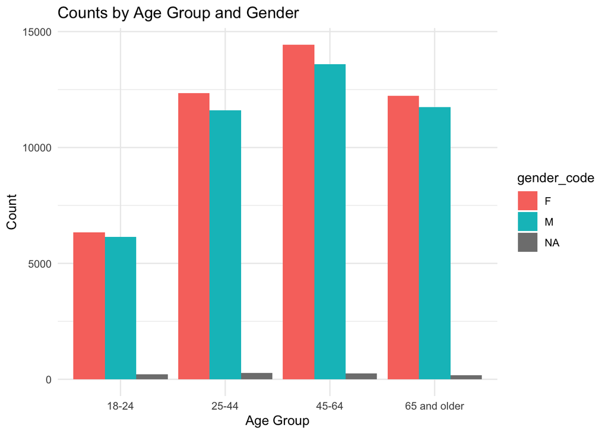

```r
ggplot(gender_age, aes(x = age_group, y = count, fill = gender_code)) +
  geom_bar(stat = "identity", position = "dodge") +
  labs(title = "Counts by Age Group and Gender",
       x = "Age Group",
       y = "Count") +
  theme_minimal()
```

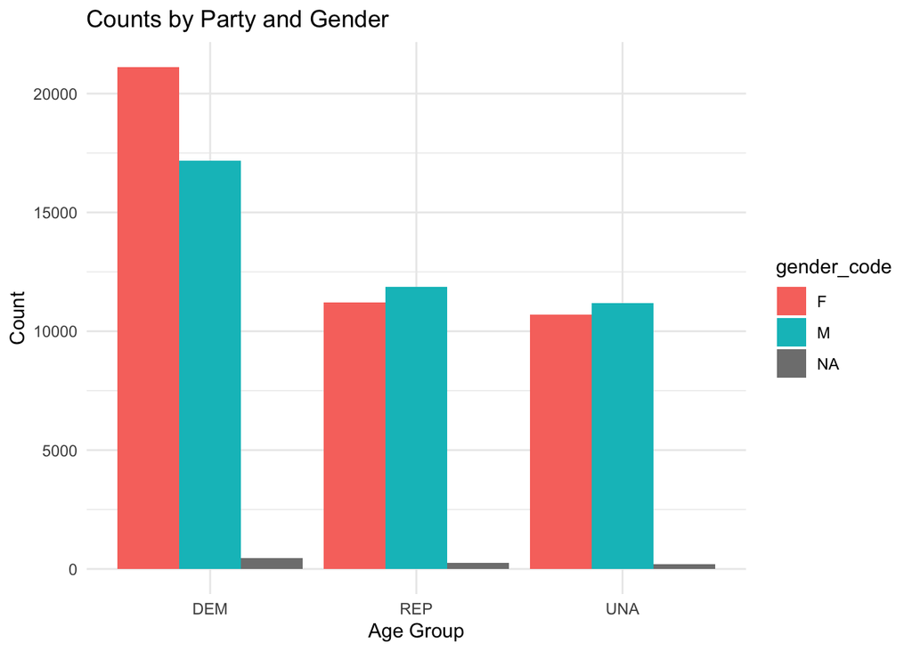

```r
ggplot(gender_party, aes(x = party_code, y = count, fill = gender_code)) +
 geom_bar(stat = "identity", position = "dodge") +
  labs(title = "Counts by Party and Gender",
       x = "Age Group",
       y = "Count") +
  theme_minimal()
```

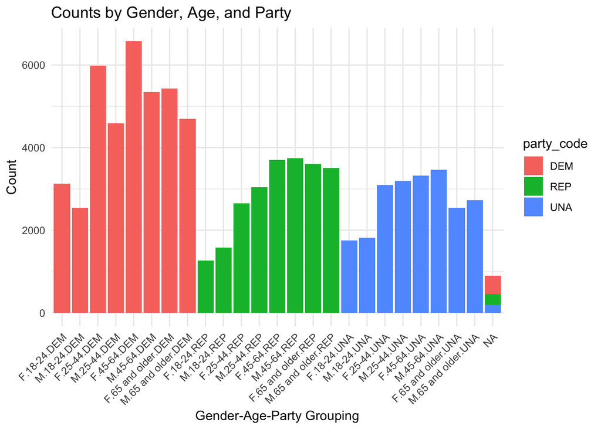

```r
ggplot(gender_age_party, aes(x = interaction(gender_code, age_group, party_code), y = count, fill = party_code)) +
  geom_bar(stat = "identity") +
  labs(title = "Counts by Gender, Age, and Party",
       x = "Gender-Age-Party Grouping",
       y = "Count") +
  theme_minimal() +
  theme(axis.text.x = element_text(angle = 45, hjust = 1)) # Rotates x-axis labels for readability
```

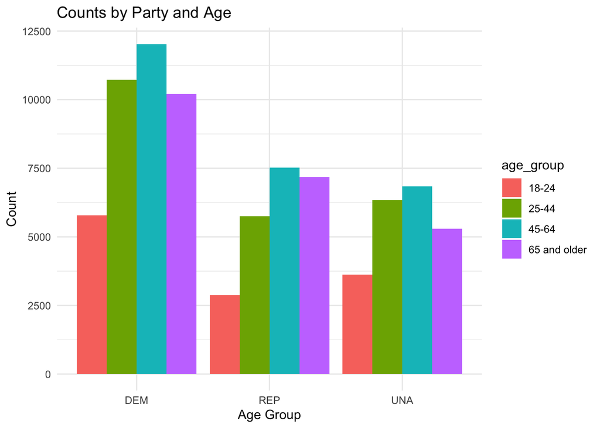

```r
ggplot(age_party, aes(x = party_code, y = count, fill = age_group)) +
 geom_bar(stat = "identity", position = "dodge") +
  labs(title = "Counts by Party and Age",
       x = "Age Group",
       y = "Count") +
  theme_minimal()
```

Overall findings: 45-64 year olds are turning out in higher numbers, and women of all age groups are turning out slightly higher than men. Basically everyone except 18-24 year olds are turning out in fairly high numbers. Democrat women are the largest group, followed by democrat men. Republican and Unaffiliated men are turning out at similar rates, as are Republican and Unaffiliated women. Interestingly, they are turning out at similar rates. Democrat women in the 45-64 age range are the top early voting group, followed by dem women ages 25-44. Democrats ages 25 and up are the top voters turning out early. Unaffiliated voters under 25 are turning out higher than young republicans, same for UNA 25-44. Older republicans (45 and up) are the only ones turning out higher than unaffiliated voters.

gender/age/county gender/party/county gender/age/party/county age/party? age/county? age/party/county party/county?

```r
age_county <- early_voting |>
  group_by(age_group, county_name) |>
  summarise(count=n())
gender_party_county <- early_voting |>
  filter(party_code %in% c("DEM", "REP", "UNA")) |>
  group_by(gender_code, party_code, county_name) |>
  summarise(count=n())
age_county <- left_join(age_county, adult_pop, by = "county_name") |>
  mutate(per_10k = count/population*10000)

gender_party_county <- left_join(gender_party_county, adult_pop, by = "county_name") |>
  mutate(per_10k = count/population*10000)

age_county |>
  arrange(desc(per_10k))
```

```
## # A tibble: 96 × 5
## # Groups:   age_group [4]
##    age_group    county_name  count population per_10k
##    <chr>        <chr>        <int>      <dbl>   <dbl>
##  1 65 and older Dorchester     211      17119    123.
##  2 65 and older Somerset       133      11299    118.
##  3 45-64        Anne Arundel  3445     293531    117.
##  4 45-64        Dorchester     195      17119    114.
##  5 45-64        Somerset       122      11299    108.
##  6 45-64        Garrett        151      14468    104.
##  7 65 and older Garrett        149      14468    103.
##  8 25-44        Anne Arundel  3014     293531    103.
##  9 45-64        Montgomery    5551     542909    102.
## 10 45-64        Wicomico       540      53805    100.
## # ℹ 86 more rows
```

```r
gender_party_county |>
  arrange(desc(per_10k))
```

```
## # A tibble: 208 × 6
## # Groups:   gender_code, party_code [9]
##    gender_code party_code county_name     count population per_10k
##    <chr>       <chr>      <chr>           <int>      <dbl>   <dbl>
##  1 F           DEM        Prince George's  4637     494721    93.7
##  2 F           DEM        Baltimore City   2771     313419    88.4
##  3 F           DEM        Montgomery       4234     542909    78.0
##  4 M           REP        Garrett           108      14468    74.6
##  5 M           DEM        Prince George's  3688     494721    74.5
##  6 F           DEM        Anne Arundel     2180     293531    74.3
##  7 M           REP        Dorchester        126      17119    73.6
##  8 F           REP        Garrett           104      14468    71.9
##  9 F           REP        Dorchester        123      17119    71.8
## 10 M           REP        Somerset           81      11299    71.7
## # ℹ 198 more rows
```